```r
library(RColorBrewer)
library(ggplot2)
library(ggExtra)
library(patchwork)
library(tidyverse)
library(vioplot)
library(hrbrthemes)
```

# Car information dataset analysis.

1. Name: Unique identifier for each automobile.
2. MPG: Fuel efficiency measured in miles per gallon.
3. Cylinders: Number of cylinders in the engine.
4. Displacement: Engine displacement, indicating its size or capacity.
5. Horsepower: Power output of the engine.
6. Weight: Weight of the automobile in pounds.
7. Acceleration: Capability to increase speed, measured in seconds to 60 miles/hour.
8. Model Year: Year of manufacture for the automobile model.
9. Origin: Country or region of origin for each automobile.

The dataset can be found via this [**link**](https://www.kaggle.com/datasets/tawfikelmetwally/automobile-dataset)

## Data exploration

```r
setwd("/media/sf_SF/Fedora/R_course/Assignment/")
car_data <- read.csv("Automobile.csv")
head(car_data)
```

```
##                        name mpg cylinders displacement horsepower weight
## 1 chevrolet chevelle malibu  18         8          307        130   3504
## 2         buick skylark 320  15         8          350        165   3693
## 3        plymouth satellite  18         8          318        150   3436
## 4             amc rebel sst  16         8          304        150   3433
## 5               ford torino  17         8          302        140   3449
## 6          ford galaxie 500  15         8          429        198   4341
##   acceleration model_year origin
## 1         12.0         70    usa
## 2         11.5         70    usa
## 3         11.0         70    usa
## 4         12.0         70    usa
## 5         10.5         70    usa
## 6         10.0         70    usa
```

```r
str(car_data)
```

```
## 'data.frame':    398 obs. of  9 variables:
##  $ name        : chr  "chevrolet chevelle malibu" "buick skylark 320" "plymouth satellite" "amc rebel sst" ...
##  $ mpg         : num  18 15 18 16 17 15 14 14 14 15 ...
##  $ cylinders   : int  8 8 8 8 8 8 8 8 8 8 ...
##  $ displacement: num  307 350 318 304 302 429 454 440 455 390 ...
##  $ horsepower  : int  130 165 150 150 140 198 220 215 225 190 ...
##  $ weight      : int  3504 3693 3436 3433 3449 4341 4354 4312 4425 3850 ...
##  $ acceleration: num  12 11.5 11 12 10.5 10 9 8.5 10 8.5 ...
##  $ model_year  : int  70 70 70 70 70 70 70 70 70 70 ...
##  $ origin      : chr  "usa" "usa" "usa" "usa" ...
```

Let’s check if there are empty values

```r
missing_values <- which(is.na(car_data), arr.ind = TRUE)
print(missing_values)
```

```
##      row col
## [1,]  33   5
## [2,] 127   5
## [3,] 331   5
## [4,] 337   5
## [5,] 355   5
## [6,] 375   5
```

```r
print(paste("Column 5 is",colnames(car_data)[5]))
```

```
## [1] "Column 5 is horsepower"
```

There are six missing values in the horsepower column.

IMPORTANT NOTE: The amount of cylinders also falls under categorical variable, as it devides the cars in categorical groups based on their engine. Also, the miles per gallon will be ignored, because the mpg values will be calcated to liters/100k, which will be placed inside a new column

```r
car_data$model_year <- as.character(car_data$model_year)
car_data$model_year <- paste0("19",car_data$model_year)
car_data$cylinders <- as.character(car_data$cylinders)
car_data$L_100km <- 235.215 / car_data$mpg
cat_var <- c("name", "brand", "model_year", "origin", "cylinders")
num_var <- c("L_100km", "displacement", "horsepower", "weight", "acceleration")
```

Let’s take a look at the frequencies of each categorical variable. Because of the huge amount of unique car models, no representative barplot can be generated. The complete dataset contains 37 car brands

```r
car_data$brand <- sapply(strsplit(car_data$name, " "), `[`, 1)

paste0("Unique car models: ",length(unique(car_data$name)),', Unique car brands: ', length(unique(car_data$brand)))
```

```
## [1] "Unique car models: 305, Unique car brands: 37"
```

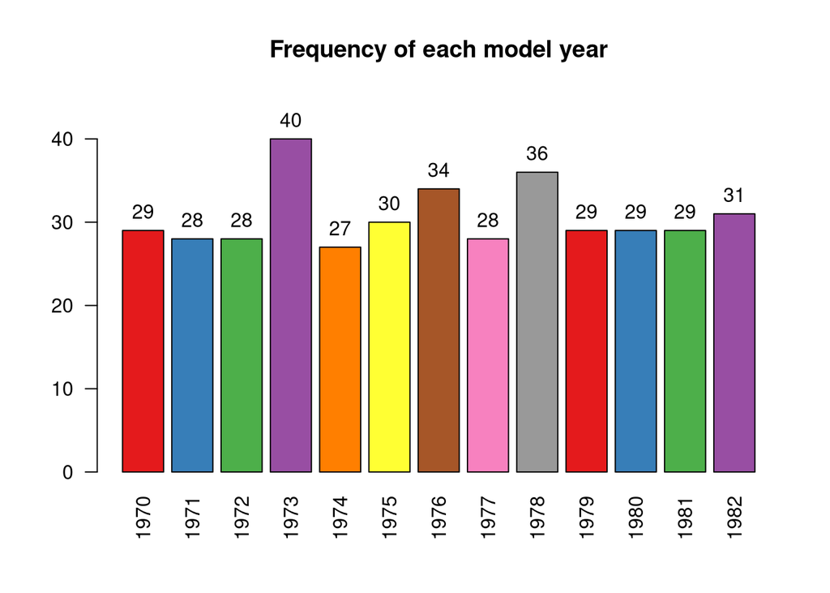

```r
bp <- barplot(table(car_data$model_year),
        main = "Frequency of each model year",
        ylim = c(0,45),
        col = brewer.pal(12, "Set1"),
        las = 2)
text(x=bp, y=table(car_data$model_year),label=table(car_data$model_year),pos=3)
```

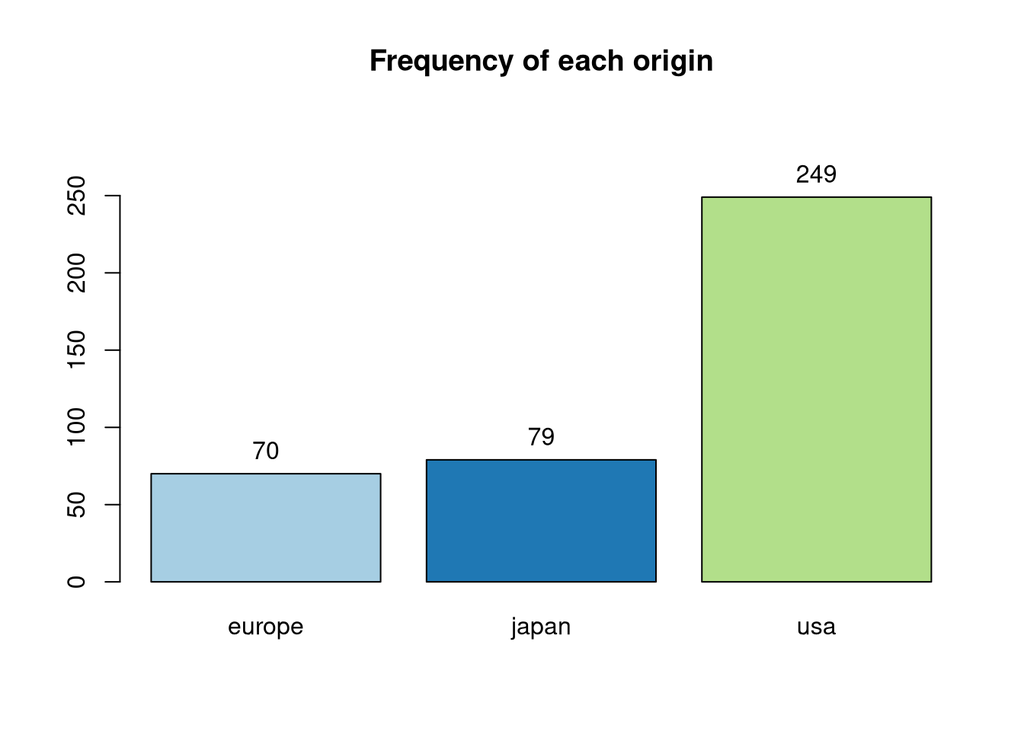

```r
bp <- barplot(table(car_data$origin),
        main = "Frequency of each origin",
        ylim = c(0,max(table(car_data$origin))+50),
        col = brewer.pal(3, "Paired"))
text(x=bp, y=table(car_data$origin),label=table(car_data$origin),pos=3)
```

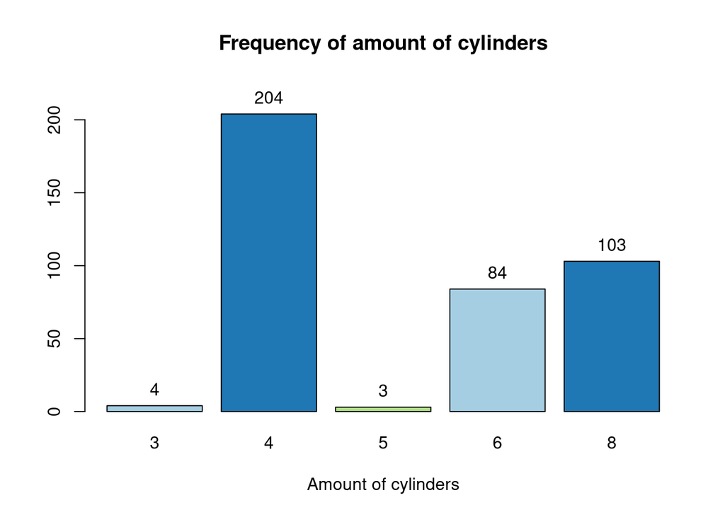

```r
bp <- barplot(table(car_data$cylinders),
        main = "Frequency of amount of cylinders",
        xlab = "Amount of cylinders",
        ylim = c(0,max(table(car_data$cylinders)+20)),
        col = brewer.pal(3, "Paired"))
text(x=bp, y=table(car_data$cylinders),label=table(car_data$cylinders),pos=3)
```

Let’s take a look at density and distribution of the numerical variables now.

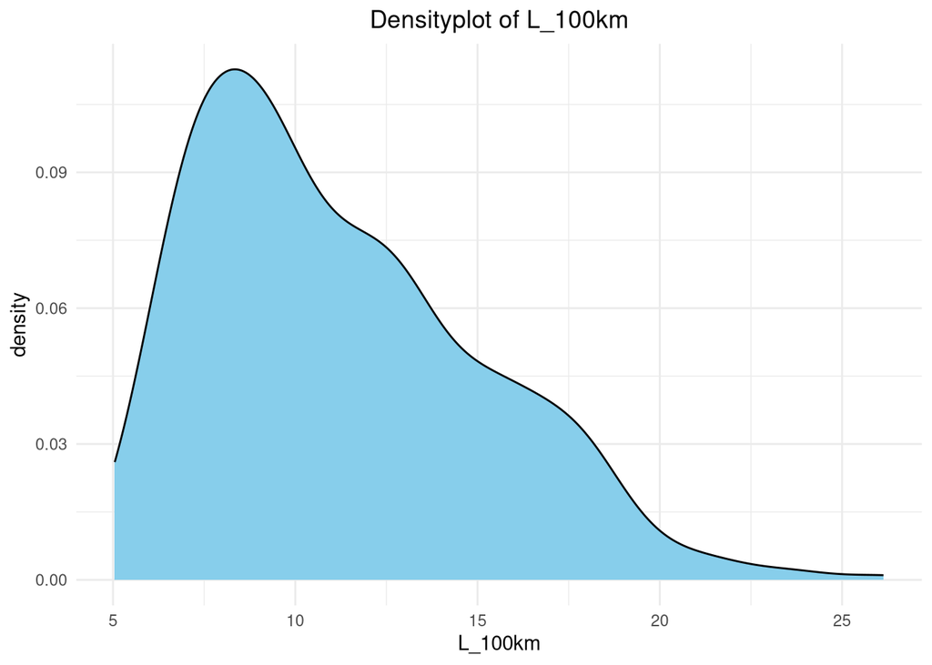

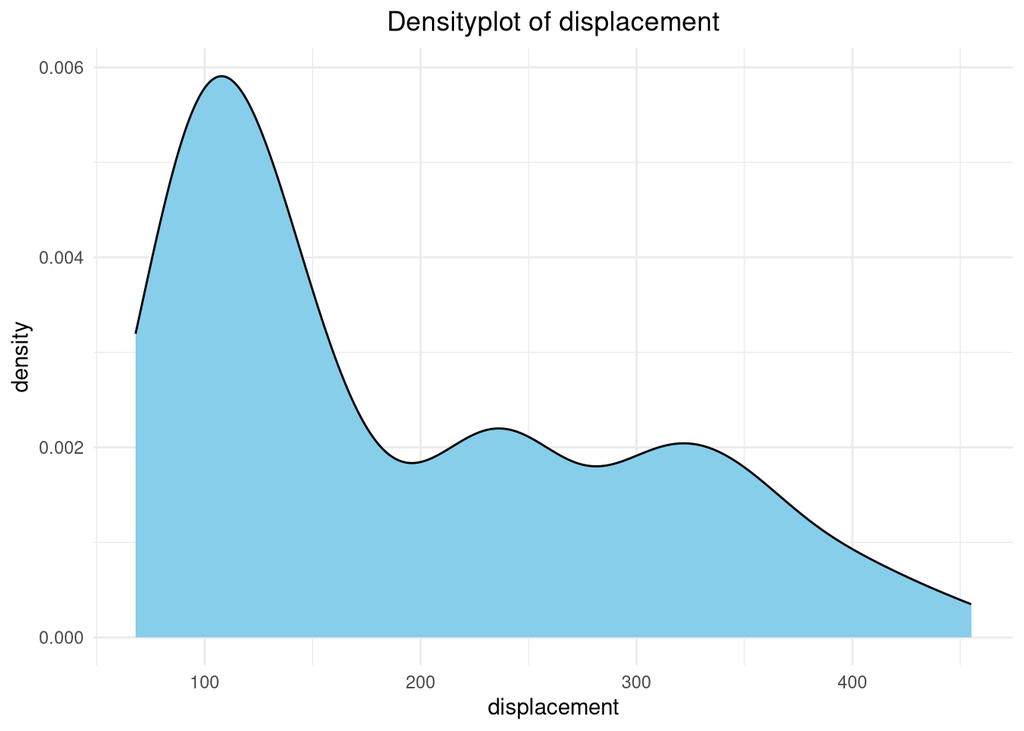

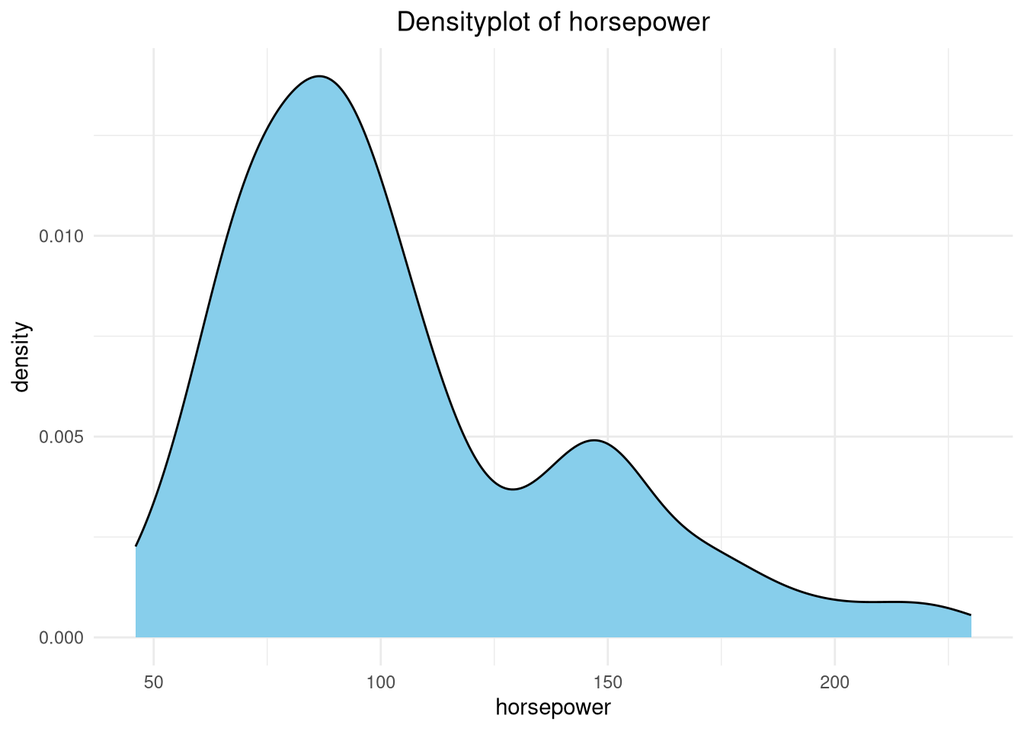

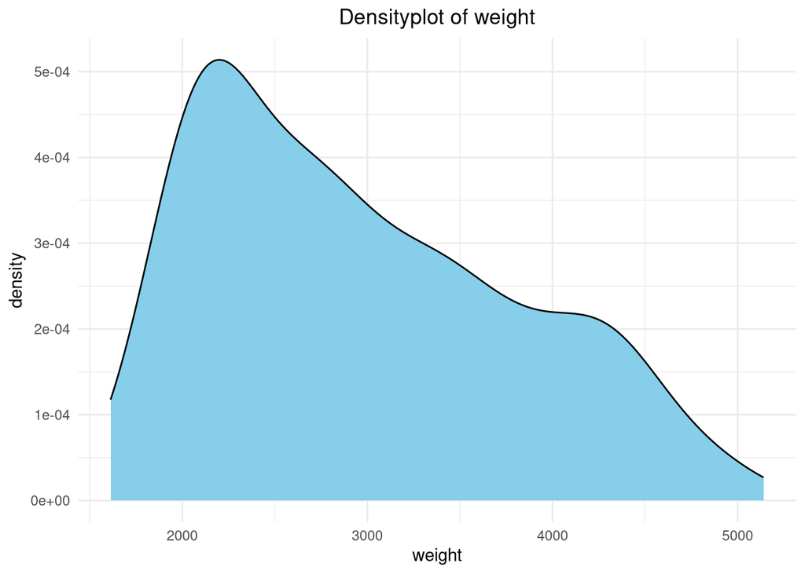

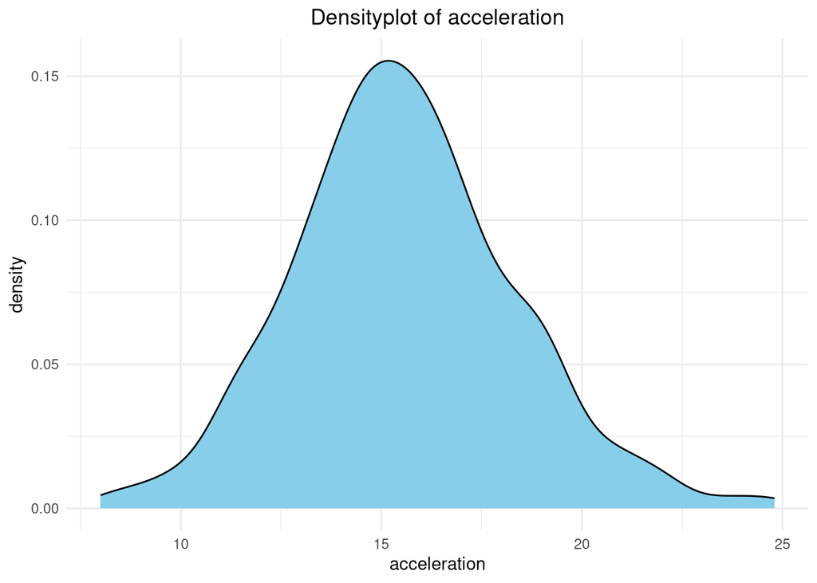

```r
for (var in num_var) {
  p <- ggplot(car_data, aes(x = !!sym(var))) +
    geom_density(fill = "skyblue", color = "black") +
    labs(title = paste("Densityplot of", var)) +
    theme_minimal() +
    theme(plot.title = element_text(hjust = 0.5))
  print(p)
}
```

The acceleration variable has a normal distribution. The other numerical variables have a right skewness

With this dataset, some genereal research questions can be asked. Firstly, do the amount of cylinders have a correlation with the numerical variables? To start, let’s make some boxplots of the numerical variables, grouped by the amount of cylinders of the engine.

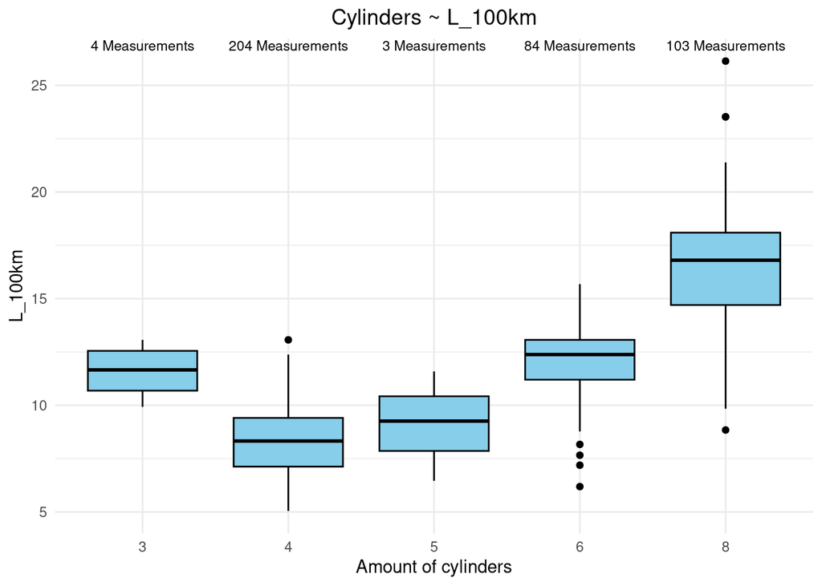

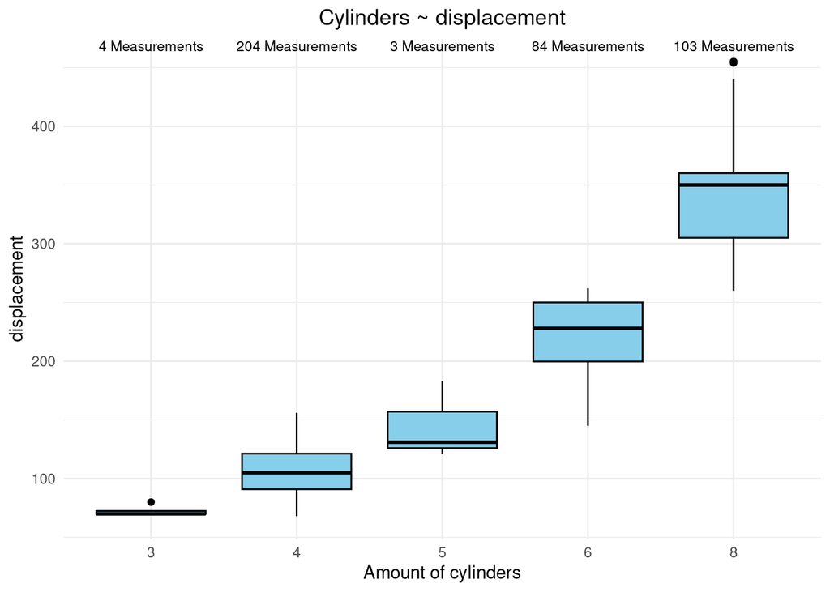

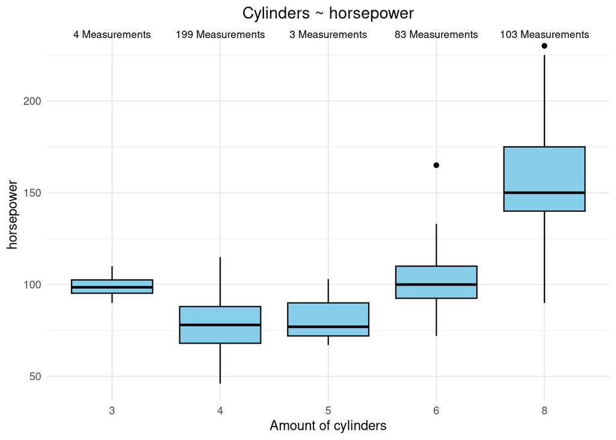

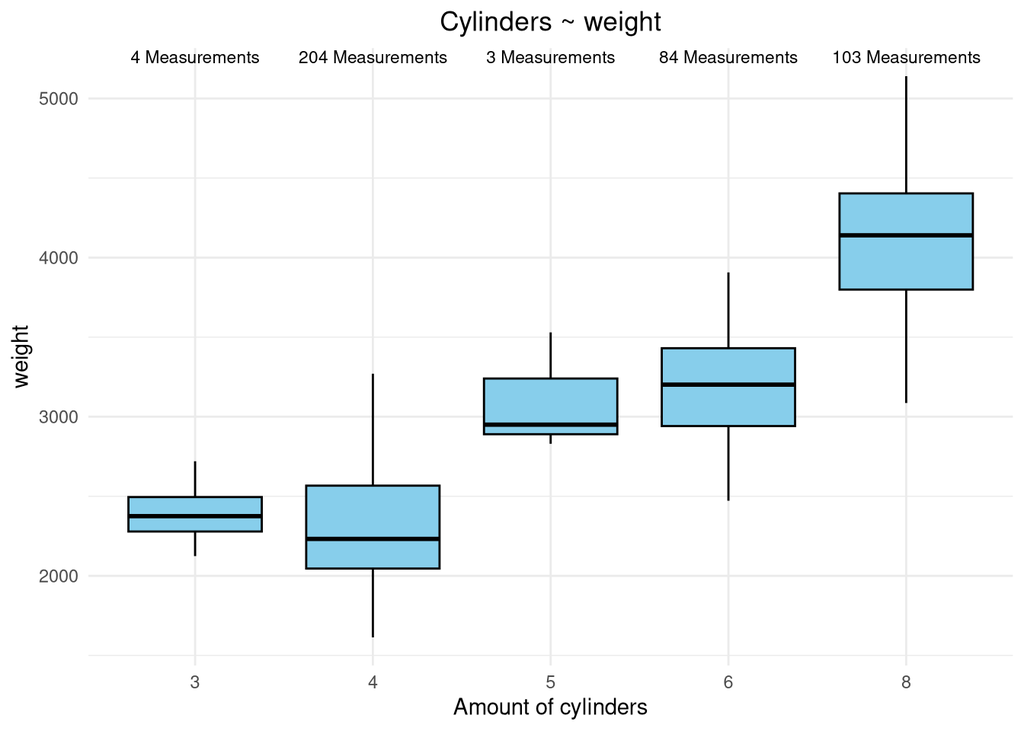

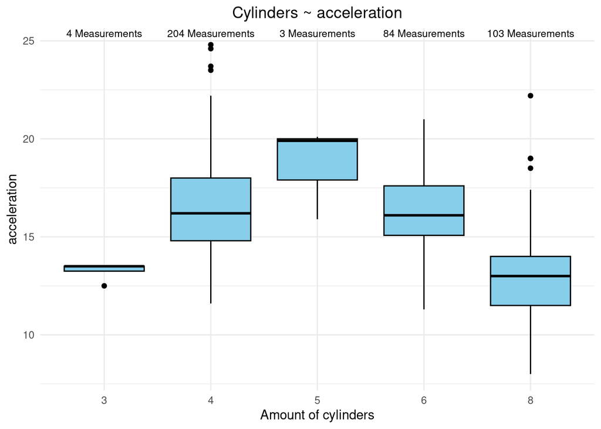

```r
for (i in num_var) {
  measurements <- car_data %>%
  group_by(cylinders) %>%
  summarise(count = sum(!is.na(!!sym(i))))

  p <- ggplot(car_data, aes(x = as.factor(cylinders), y = !!sym(i))) +
    geom_boxplot(fill = "skyblue", color = "black") +
    geom_text(data = measurements,aes(label = paste(count, "Measurements"),
                  y = max(car_data[[i]], na.rm = TRUE)),
              vjust = -1, size = 3) +
    labs(title = paste("Cylinders ~", i), x = "Amount of cylinders") +
    theme_minimal() +
     theme(plot.title = element_text(hjust = 0.5))
  print(p)
}
```

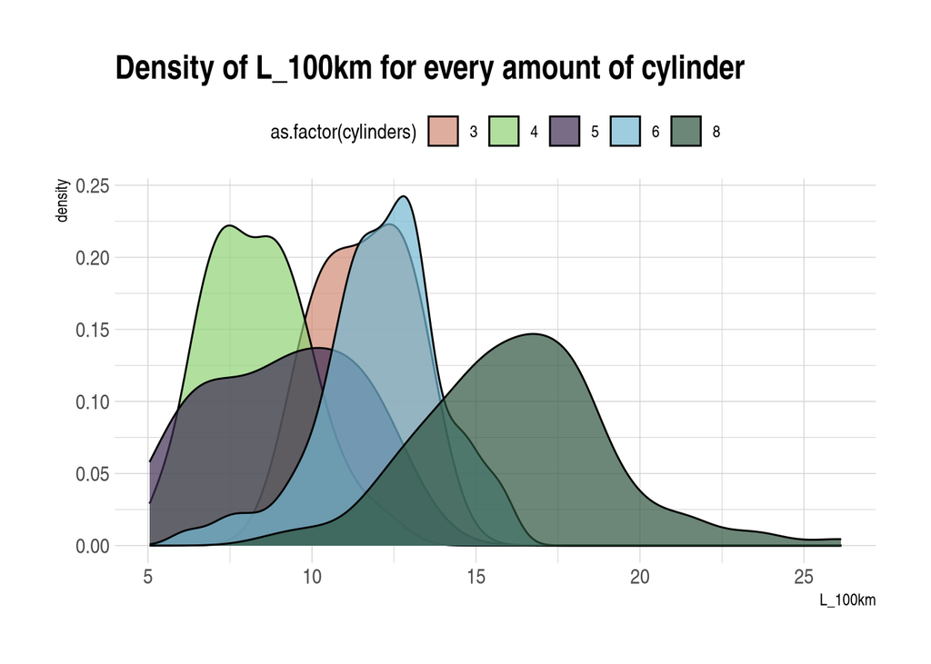

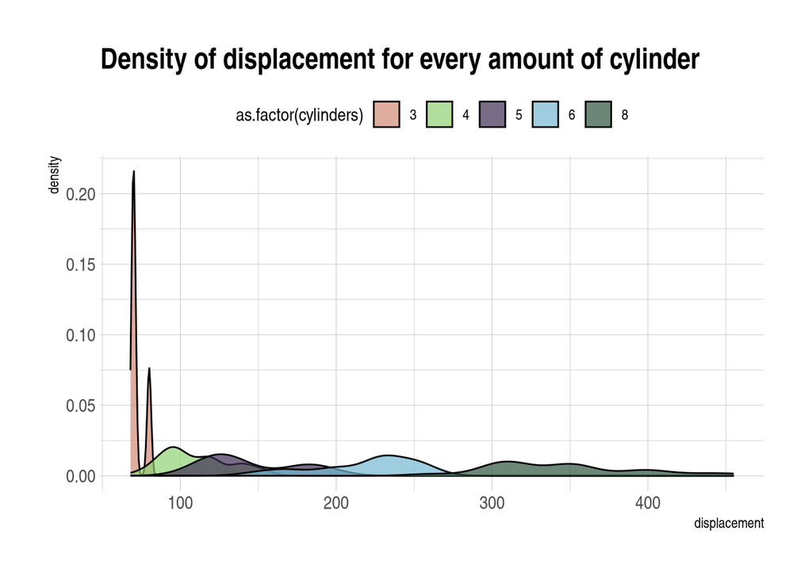

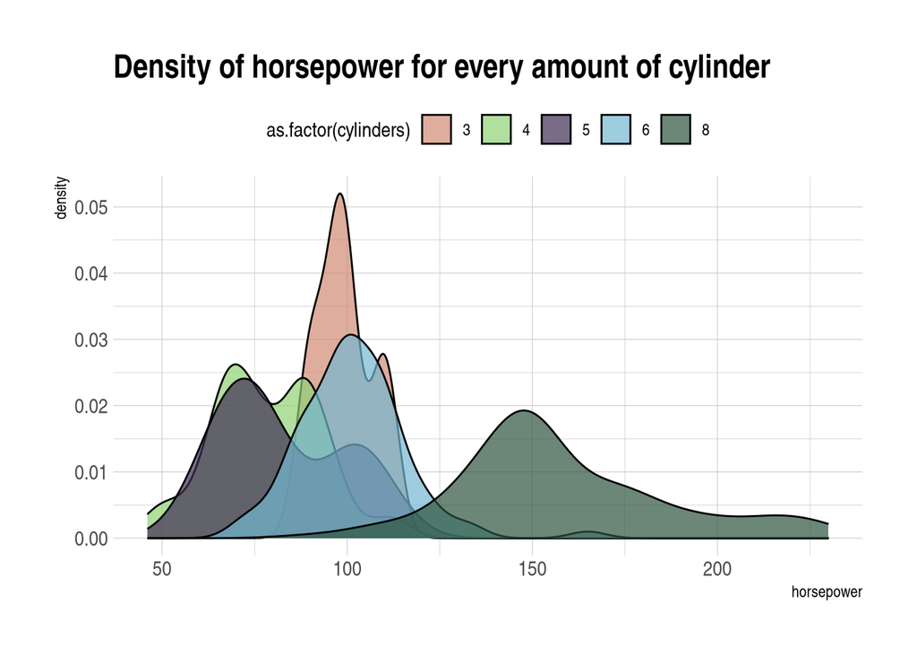

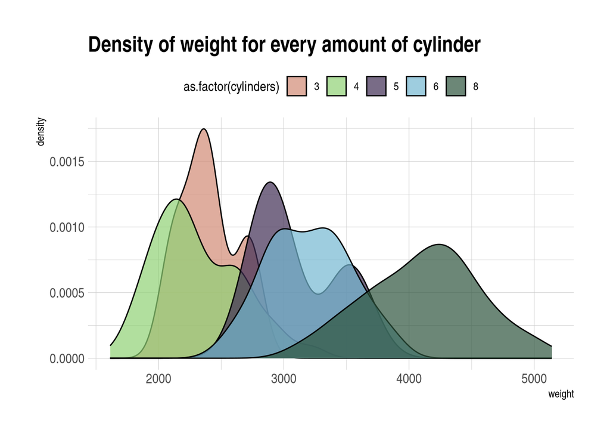

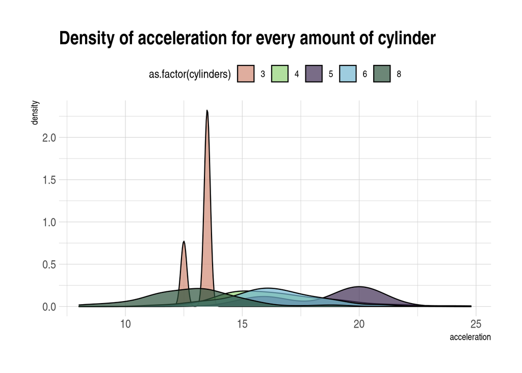

```r
for (i in num_var){
  p <- ggplot(car_data, aes(x = car_data[,i], fill = as.factor(cylinders))) +
    geom_density(alpha = 0.7) +
    labs(title = paste("Density of",i,"for every amount of cylinder"),
         x = i) +
    theme_ipsum() +
    scale_fill_ipsum() +
    theme(legend.position = "top")
  print(p)
}
```

Let’s make a scatterplot to further investigate the correlatations.

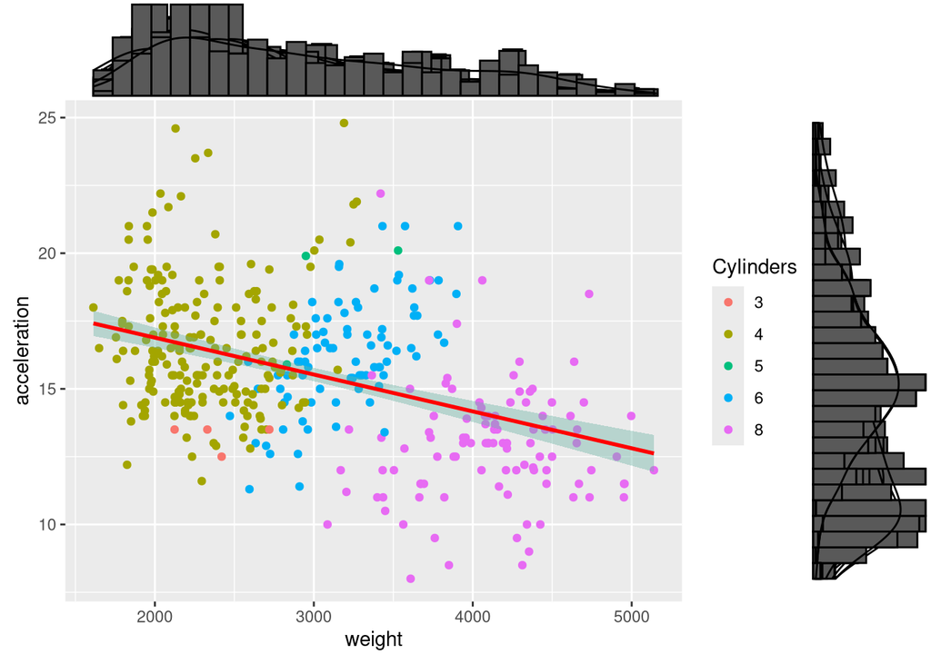

```r
for (i in 1:length(num_var)) {
  for (j in (i + 1):length(num_var)) {  # Start from i + 1 to avoid duplicates
    if (i != j && !is.na(num_var[i]) && !is.na(num_var[j])) {
      p <- ggplot(car_data, aes_string(x = num_var[i],
                                       y = num_var[j],
                                       color = "cylinders")) +
        geom_point() +
        geom_smooth(method=lm , color="red", fill="#69b3a2", se=TRUE) +
        theme(legend.position = "right") +
        labs(color = "Cylinders")

      p2 <- ggMarginal(p, type = "densigram")
      print(p2)
    }
  }
}
```

[output not shown]

A second research question that can be asked, is if there any difference in the numerical variables between the origins of the cars? To check this, a violin plot was made.

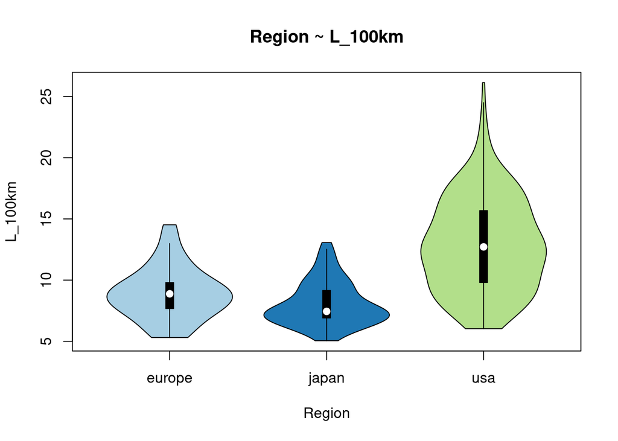

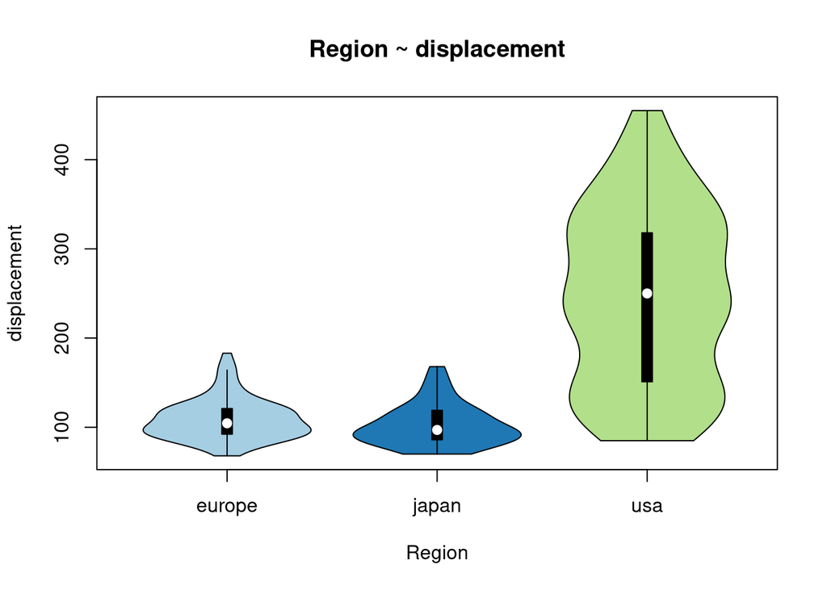

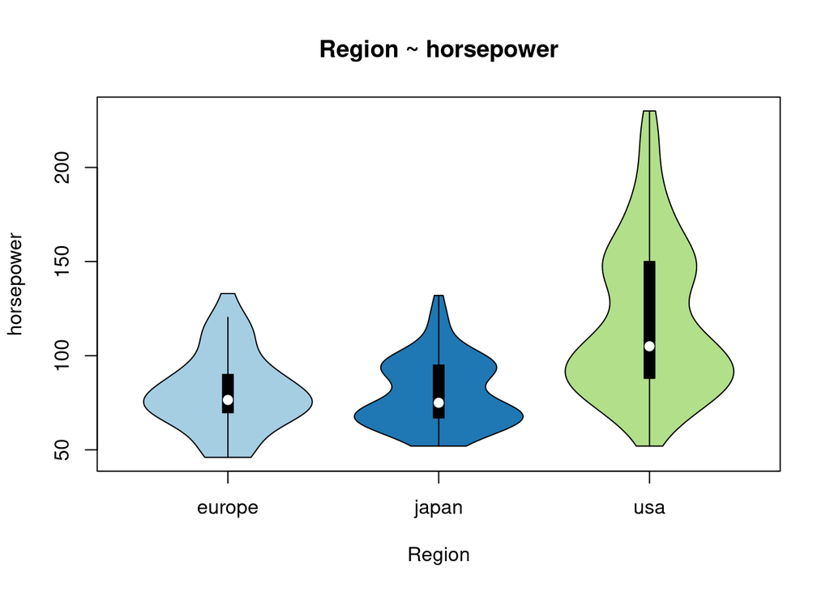

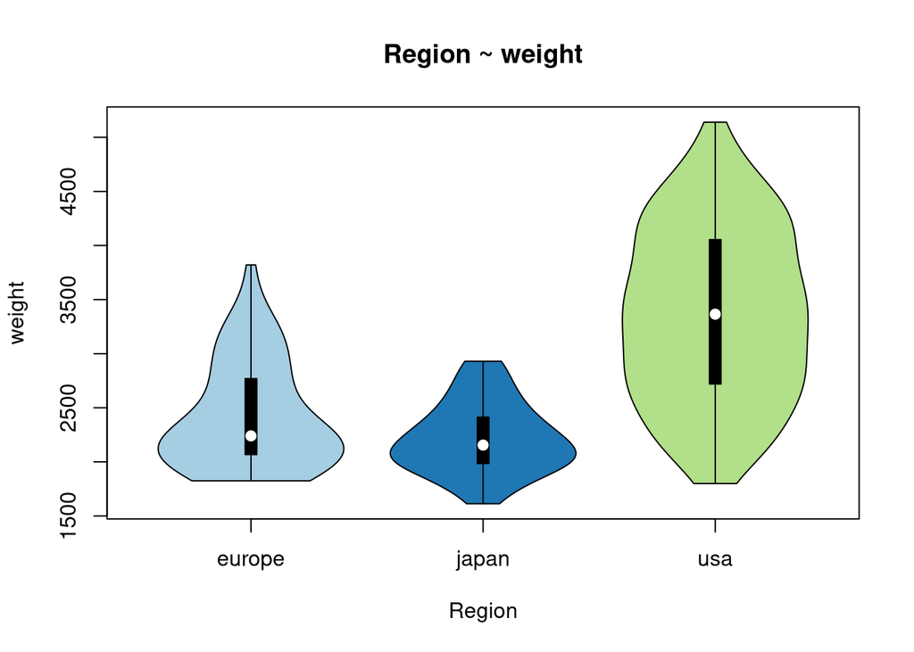

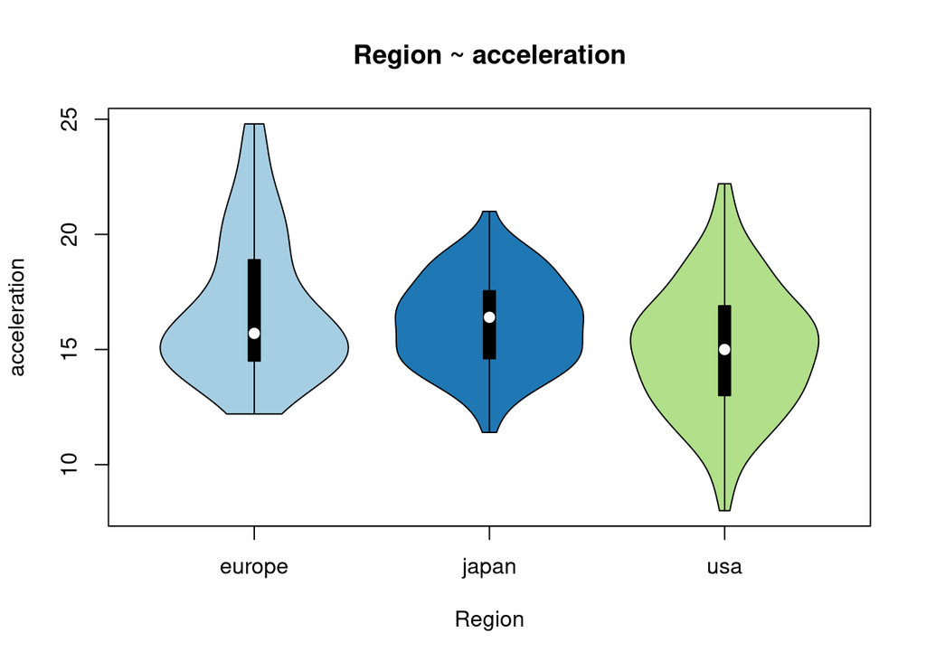

```r
for (i in num_var) {
  p <- vioplot(car_data[,i] ~ car_data$origin,
               col = brewer.pal(3, "Paired"),
               xlab = "Region",
               ylab = paste(i),
               main = paste("Region ~",i))
  p
}
```

Laslty, lets’s check whether the origin of the car, or the amount of cylinders cluster together. To analyse this, a principle component analysis was performed.

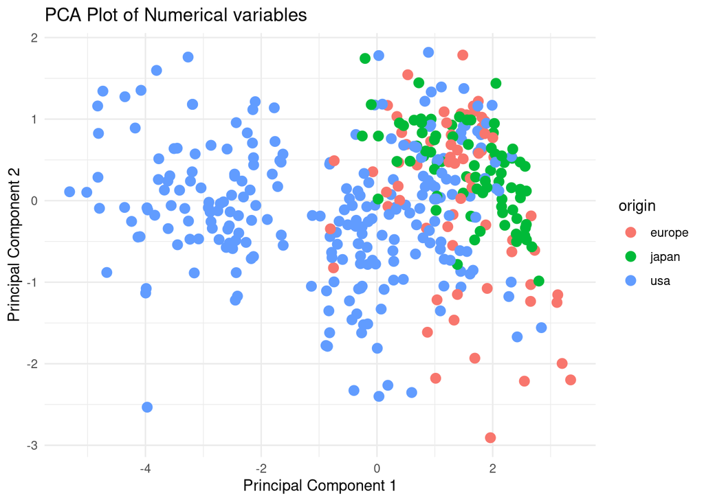

```r
car_data_copy <- car_data
car_data_copy <- na.omit(car_data_copy)
pca_result <- prcomp(na.omit(car_data_copy[num_var]), scale. = TRUE, center = TRUE)
pca_df <- as.data.frame(pca_result$x)
pca_df <- cbind(pca_df, origin = car_data_copy$origin)

# Create the PCA plot with origin coloring
ggplot(pca_df, aes(x = PC1, y = PC2, color = origin)) +
  geom_point(size = 3) +
  labs(title = "PCA Plot of Numerical variables",
       x = "Principal Component 1",
       y = "Principal Component 2") +
  theme_minimal()
```

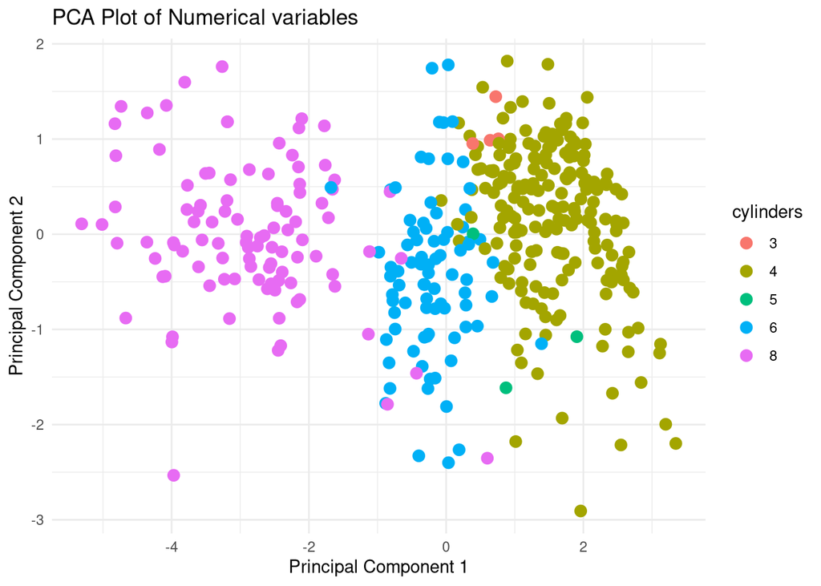

```r
pca_df <- cbind(pca_df, cylinders = car_data_copy$cylinders)
# Create the PCA plot with cylinder coloring
ggplot(pca_df, aes(x = PC1, y = PC2, color = cylinders)) +
  geom_point(size = 3) +
  labs(title = "PCA Plot of Numerical variables",
       x = "Principal Component 1",
       y = "Principal Component 2") +
  theme_minimal()
```